# DILI

Authors

Affiliation

Tran Thai Hung

OUCRU biostat

Ronald Geskus

OUCRU biostat

Published

Last version: April 03, 2026

Keywords

DILI

## 1. Baseline table

| Characteristic | N | Overall N = 671 | Strategy 1: Observe N = 211 | Strategy 2: Stop Z N = 211 | Strategy 3: Stop RHZ N = 251 |
| --- | --- | --- | --- | --- | --- |
| Age [years] | 67 | 39 (34, 48) | 36 (30, 47) | 41 (34, 52) | 40 (36, 47) |
| Sex | 67 |  |  |  |  |
| Female |  | 24 (35.8%) | 9 (42.9%) | 6 (28.6%) | 9 (36.0%) |
| Male |  | 43 (64.2%) | 12 (57.1%) | 15 (71.4%) | 16 (64.0%) |
| Site | 67 |  |  |  |  |
| HTD |  | 35 (52.2%) | 11 (52.4%) | 13 (61.9%) | 11 (44.0%) |
| PNT |  | 28 (41.8%) | 9 (42.9%) | 8 (38.1%) | 11 (44.0%) |
| Cipto Mangunkusumo |  | 4 (6.0%) | 1 (4.8%) | 0 (0.0%) | 3 (12.0%) |
| Persahabatan |  | 0 (0.0%) | 0 (0.0%) | 0 (0.0%) | 0 (0.0%) |
| TBM diagnosis2 | 67 |  |  |  |  |
| Definite TBM |  | 37 (55.2%) | 12 (57.1%) | 12 (57.1%) | 13 (52.0%) |
| Probable TBM |  | 19 (28.4%) | 4 (19.0%) | 6 (28.6%) | 9 (36.0%) |
| Possible TBM |  | 11 (16.4%) | 5 (23.8%) | 3 (14.3%) | 3 (12.0%) |
| Confirmed non-TBM |  | 0 (0.0%) | 0 (0.0%) | 0 (0.0%) | 0 (0.0%) |
| Modified MRC grade | 67 |  |  |  |  |
| Grade I |  | 23 (34.3%) | 5 (23.8%) | 9 (42.9%) | 9 (36.0%) |
| Grade II |  | 34 (50.7%) | 13 (61.9%) | 9 (42.9%) | 12 (48.0%) |
| Grade III |  | 10 (14.9%) | 3 (14.3%) | 3 (14.3%) | 4 (16.0%) |
| HIV status | 67 |  |  |  |  |
| Positive |  | 30 (44.8%) | 9 (42.9%) | 8 (38.1%) | 13 (52.0%) |
| Negative |  | 37 (55.2%) | 12 (57.1%) | 13 (61.9%) | 12 (48.0%) |
| Use of anti-retroviral therapy at baseline in PLWHIV | 67 |  |  |  |  |
| 3 months of ART |  | 7 (10.4%) | 1 (4.8%) | 3 (14.3%) | 3 (12.0%) |
| ART naive |  | 51 (76.1%) | 19 (90.5%) | 15 (71.4%) | 17 (68.0%) |
| Undetermined |  | 7 (10.4%) | 1 (4.8%) | 3 (14.3%) | 3 (12.0%) |
| Unknown |  | 2 (3.0%) | 0 (0.0%) | 0 (0.0%) | 2 (8.0%) |
| LTA4H genotype | 63 |  |  |  |  |
| CC |  | 27 (42.9%) | 6 (30.0%) | 11 (52.4%) | 10 (45.5%) |
| CT |  | 27 (42.9%) | 9 (45.0%) | 6 (28.6%) | 12 (54.5%) |
| TT |  | 9 (14.3%) | 5 (25.0%) | 4 (19.0%) | 0 (0.0%) |
| History of previous tuberculosis treatment | 67 |  |  |  |  |
| Yes |  | 11 (16.4%) | 2 (9.5%) | 3 (14.3%) | 6 (24.0%) |
| No |  | 53 (79.1%) | 17 (81.0%) | 17 (81.0%) | 19 (76.0%) |
| Unknown |  | 3 (4.5%) | 2 (9.5%) | 1 (4.8%) | 0 (0.0%) |
| Weight [kg] | 67 | 50 (45, 60) | 48 (45, 55) | 55 (45, 60) | 50 (45, 60) |
| Chest X-ray findings | 67 |  |  |  |  |
| Normal |  | 34 (50.7%) | 10 (47.6%) | 12 (57.1%) | 12 (48.0%) |
| Miliary tuberculosis |  | 12 (17.9%) | 6 (28.6%) | 2 (9.5%) | 4 (16.0%) |
| Pulmonary tuberculosis |  | 21 (31.3%) | 5 (23.8%) | 7 (33.3%) | 9 (36.0%) |
| Hepatitis B sAg positivity | 66 |  |  |  |  |
| Negative |  | 61 (92.4%) | 19 (95.0%) | 19 (90.5%) | 23 (92.0%) |
| Positive |  | 5 (7.6%) | 1 (5.0%) | 2 (9.5%) | 2 (8.0%) |
| Hepatitis C Ab positivity | 67 |  |  |  |  |
| Negative |  | 59 (88.1%) | 18 (85.7%) | 18 (85.7%) | 23 (92.0%) |
| Positive |  | 8 (11.9%) | 3 (14.3%) | 3 (14.3%) | 2 (8.0%) |
| Alanine aminotransferase (ALT) [IU/L] | 67 | 35 (20, 63) | 31 (16, 57) | 46 (32, 65) | 33 (20, 52) |
| Bilirubin [µmol/L] | 67 | 14 (10, 21) | 14 (10, 17) | 16 (10, 23) | 12 (9, 18) |
| INR | 57 | 1.0 (1.0, 1.2) | 1.1 (1.0, 1.1) | 1.1 (1.0, 1.2) | 1.0 (1.0, 1.1) |
| CSF measurements |  |  |  |  |  |
| Total leucocytes [cells/mm^3] | 67 | 173 (41, 353) | 165 (20, 312) | 310 (130, 462) | 130 (25, 280) |
| Total neutrophils [cells/mm^3] | 67 | 18 (0, 84) | 12 (0, 32) | 20 (10, 129) | 33 (1, 62) |
| Total lymphocytes [cells/mm^3] | 67 | 117 (22, 250) | 53 (20, 248) | 168 (117, 360) | 85 (7, 174) |
| Protein [g/L] | 67 | 1.6 (1.0, 2.5) | 1.4 (0.7, 2.7) | 1.9 (1.1, 3.0) | 1.6 (1.0, 2.1) |
| CSF:Blood glucose ratio | 67 | 0.37 (0.22, 0.46) | 0.44 (0.16, 0.52) | 0.32 (0.24, 0.46) | 0.37 (0.30, 0.43) |
| CSF microbiological tests |  |  |  |  |  |
| Positive ZN stain | 63 | 26 (41.3%) | 7 (35.0%) | 10 (50.0%) | 9 (39.1%) |
| Positive GeneXpert MTB/RIF | 56 | 11 (19.6%) | 2 (13.3%) | 6 (30.0%) | 3 (14.3%) |
| Positive GeneXpert MTB/RIF Ultra | 47 | 12 (25.5%) | 7 (38.9%) | 1 (7.1%) | 4 (26.7%) |
| Positive mycobacterial culture | 66 | 22 (33.3%) | 7 (33.3%) | 9 (42.9%) | 6 (25.0%) |
| Main trial enrolment anti-tuberculosis chemotherapy regimen |  |  |  |  |  |
| Rifampicin | 67 | 67 (100.0%) | 21 (100.0%) | 21 (100.0%) | 25 (100.0%) |
| Isoniazid | 67 | 67 (100.0%) | 21 (100.0%) | 21 (100.0%) | 25 (100.0%) |
| Pyrazinamide | 67 | 67 (100.0%) | 21 (100.0%) | 21 (100.0%) | 25 (100.0%) |
| Ethambutol | 67 | 53 (79.1%) | 18 (85.7%) | 16 (76.2%) | 19 (76.0%) |
| Streptomycin | 67 | 22 (32.8%) | 7 (33.3%) | 7 (33.3%) | 8 (32.0%) |
| Main trial enrolment anti-tuberculosis chemotherapy dose |  |  |  |  |  |
| Rifampicin | 67 | 450 (450, 600) | 450 (450, 600) | 600 (450, 600) | 450 (450, 600) |
| Isoniazid | 67 | 225 (225, 300) | 225 (225, 300) | 300 (225, 300) | 225 (225, 300) |
| Pyrazinamide | 67 | 1,200 (1,200, 1,600) | 1,200 (1,200, 1,600) | 1,600 (1,200, 1,600) | 1,200 (1,200, 1,600) |
| Streptomycin | 22 | 750 (750, 1,000) | 750 (667, 750) | 750 (750, 1,000) | 875 (750, 1,000) |
| Ethambutol | 53 | 1,000 (800, 1,200) | 800 (800, 1,100) | 1,200 (800, 1,200) | 800 (800, 1,200) |
| Primary randomisation arm | 67 |  |  |  |  |
| Placebo |  | 34 (50.7%) | 9 (42.9%) | 13 (61.9%) | 12 (48.0%) |
| Dexamethasone |  | 33 (49.3%) | 12 (57.1%) | 8 (38.1%) | 13 (52.0%) |

1Summary statistic = the median (1st and 3rd quartile) value for numeric data, and the number and frequency (%) of patients with the characteristic for categorical data.  
2Participants will only be categorised as ‘not TBM’ if they have a confirmed alternative diagnosis (alternative to TBM) or if they fully recovered without any anti-TB drugs. Definite TBM = positive acid fast bacilli (AFB) on CSF Ziehl Neelsen stain, or positive CSF TB GeneXpert test, OR positive CSF TB culture. Probable or possible TBM defined following uniform case defintion, with the modification that participants with score<6, who do not meet the criteria for ‘not tuberculous meningitis’, will be classifed as ‘possible TBM’. Confirmed not-TBM = microbiologically confirmed other brain infection. Confirmed additional brain infection includes positive CSF India Ink stain, or CSF cryptococcal antigen, or positive blood cryptococcal antigen, or positive CSF bacterial Gram stain, or positive CSF bacterial culture, or positive CSF viral or helminth PCR test.  
HTD=Hospital for Tropical Diseases. MDR=multi-drug resistant. MRC=Medical Research Council. PNT=Pham Ngoc Thach Hospital for Tuberculosis and Lung Disease. TBM=tuberculous meningitis. ZN=Ziehl Neelsen.

## 2. Primary analysis:

### 2.1 Distribution of number of days of drug-free days over individuals

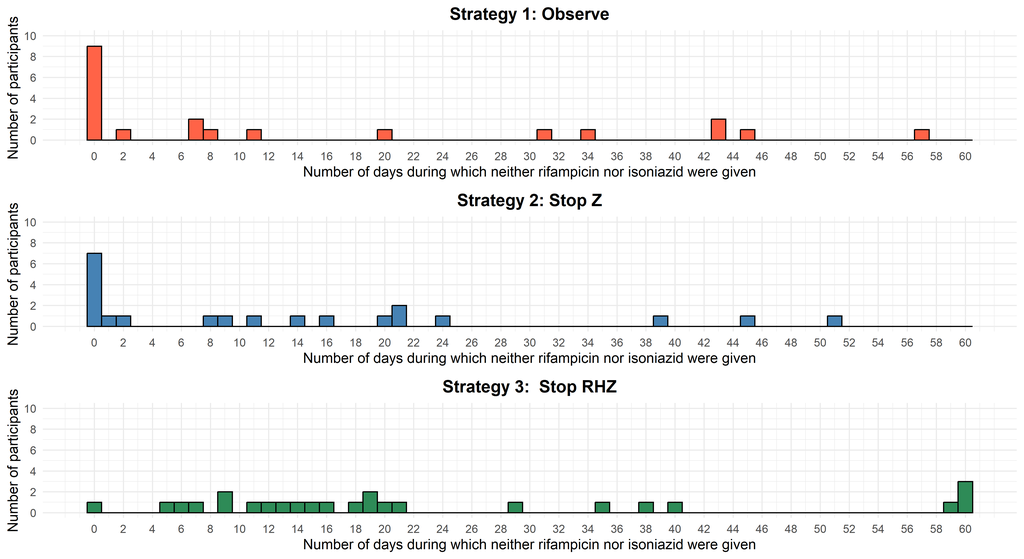

### 2.2 Primary outcome:

The proportion of time in the 60 days following randomisation during which neither rifampicin nor isoniazid were given, for strategy 1 vs. strategy 3, and strategy 2 vs. strategy 3, respectively.

For the analysis of the primary outcome, the non-parametric Wilcoxon rank-sum test was used for pairwise comparisons. As a second approach that provides a more interpretable quantification, we used beta regression.

Sub-group analyses of the primary outcome were performed for corticosteroids allocation (yes or no), HIV status at enrolment (positive or negative), and time from primary randomisation to secondary DILI randomisation. For corticosteroid allocation and HIV status we performed the analysis by subgroup. Time from randomisation was used as numeric variable and an interaction with treatment arm was included in the model. We computed the p-value of the test for heterogeneity via a beta-regression model.

**Overall**

|  | Strategy 1: Observe N | Strategy 1: Observe Summary statistic (Median [1st, 3rd quartiles]) | Strategy 3: Stop RHZ N | Strategy 3: Stop RHZ Summary statistic (Median [1st, 3rd quartiles]) | Wilcoxon rank sum test p-value | Beta regression Difference |
| --- | --- | --- | --- | --- | --- | --- |
| days during which neither rifampicin nor isoniazid were given | 21 | 7 (0, 31) | 25 | 18 (11, 35) | 0.022 | 12.1 days (3, 21.3); p = < 0.01 |

|  | Strategy 1: Observe N | Strategy 1: Observe Summary statistic (Median [1st, 3rd quartiles]) | Strategy 3: Stop RHZ N | Strategy 3: Stop RHZ Summary statistic (Median [1st, 3rd quartiles]) | Wilcoxon rank sum test p-value | Beta regression Difference |
| --- | --- | --- | --- | --- | --- | --- |
| percent during which neither rifampicin nor isoniazid were given | 21 | 11.67 (0, 51.67) | 25 | 30 (18.33, 58.33) | 0.022 | 20.2 percent (4.9, 35.5); p = < 0.01 |

|  | Strategy 2: Stop Z N | Strategy 2: Stop Z Summary statistic (Median [1st, 3rd quartiles]) | Strategy 3: Stop RHZ N | Strategy 3: Stop RHZ Summary statistic (Median [1st, 3rd quartiles]) | Wilcoxon rank sum test p-value | Beta regression Difference |
| --- | --- | --- | --- | --- | --- | --- |
| days during which neither rifampicin nor isoniazid were given | 21 | 9 (0, 21) | 25 | 18 (11, 35) | 0.041 | 12.4 days (3.6, 21.3); p = < 0.01 |

|  | Strategy 2: Stop Z N | Strategy 2: Stop Z Summary statistic (Median [1st, 3rd quartiles]) | Strategy 3: Stop RHZ N | Strategy 3: Stop RHZ Summary statistic (Median [1st, 3rd quartiles]) | Wilcoxon rank sum test p-value | Beta regression Difference |
| --- | --- | --- | --- | --- | --- | --- |
| percent during which neither rifampicin nor isoniazid were given | 21 | 15 (0, 35) | 25 | 30 (18.33, 58.33) | 0.041 | 20.7 percent (5.9, 35.5); p = < 0.01 |

**With stratification by HIV Status**

|  | Strategy 1: Observe N | Strategy 1: Observe Summary statistic (Median [1st, 3rd quartiles]) | Strategy 3: Stop RHZ N | Strategy 3: Stop RHZ Summary statistic (Median [1st, 3rd quartiles]) | Wilcoxon rank sum test p-value | Beta regression Difference | Test for heterogeneity p-value |
| --- | --- | --- | --- | --- | --- | --- | --- |
| knowhiv |  |  |  |  |  |  | 0.42 |
| Positive | 9 | 0.00 (0.00, 20.00) | 13 | 19.00 (12.00, 40.00) | 0.063 | 14.3 days (0.1, 28.4); p = 0.048 |  |
| Negative | 12 | 7.50 (0.00, 34.00) | 12 | 17.00 (10.50, 23.00) | 0.21 | 9.5 days (-1.7, 20.7); p = 0.096 |  |

Test for heterogeneity is an Wald Test for interaction between treatment effect and each subgroup in the beta-regression model not including other variables.

|  | Strategy 1: Observe N | Strategy 1: Observe Summary statistic (Median [1st, 3rd quartiles]) | Strategy 3: Stop RHZ N | Strategy 3: Stop RHZ Summary statistic (Median [1st, 3rd quartiles]) | Wilcoxon rank sum test p-value | Beta regression Difference | Test for heterogeneity p-value |
| --- | --- | --- | --- | --- | --- | --- | --- |
| knowhiv |  |  |  |  |  |  | 0.42 |
| Positive | 9 | 0.00 (0.00, 33.33) | 13 | 31.67 (20.00, 66.67) | 0.063 | 23.8 percent (0.2, 47.3); p = 0.048 |  |
| Negative | 12 | 12.50 (0.00, 56.67) | 12 | 28.33 (17.50, 38.33) | 0.21 | 15.9 percent (-2.8, 34.6); p = 0.096 |  |

Test for heterogeneity is an Wald Test for interaction between treatment effect and each subgroup in the beta-regression model not including other variables.

|  | Strategy 2: Stop Z N | Strategy 2: Stop Z Summary statistic (Median [1st, 3rd quartiles]) | Strategy 3: Stop RHZ N | Strategy 3: Stop RHZ Summary statistic (Median [1st, 3rd quartiles]) | Wilcoxon rank sum test p-value | Beta regression Difference | Test for heterogeneity p-value |
| --- | --- | --- | --- | --- | --- | --- | --- |
| knowhiv |  |  |  |  |  |  | 0.56 |
| Positive | 8 | 5.50 (0.00, 21.75) | 13 | 19.00 (12.00, 40.00) | 0.12 | 13.3 days (-1.4, 27.9); p = 0.076 |  |
| Negative | 13 | 11.00 (0.00, 21.00) | 12 | 17.00 (10.50, 23.00) | 0.21 | 10.9 days (0.8, 21.0); p = 0.034 |  |

Test for heterogeneity is an Wald Test for interaction between treatment effect and each subgroup in the beta-regression model not including other variables.

|  | Strategy 2: Stop Z N | Strategy 2: Stop Z Summary statistic (Median [1st, 3rd quartiles]) | Strategy 3: Stop RHZ N | Strategy 3: Stop RHZ Summary statistic (Median [1st, 3rd quartiles]) | Wilcoxon rank sum test p-value | Beta regression Difference | Test for heterogeneity p-value |
| --- | --- | --- | --- | --- | --- | --- | --- |
| knowhiv |  |  |  |  |  |  | 0.56 |
| Positive | 8 | 9.17 (0.00, 36.25) | 13 | 31.67 (20.00, 66.67) | 0.12 | 22.1 percent (-2.3, 46.5); p = 0.076 |  |
| Negative | 13 | 18.33 (0.00, 35.00) | 12 | 28.33 (17.50, 38.33) | 0.21 | 18.2 percent (1.4, 34.9); p = 0.034 |  |

Test for heterogeneity is an Wald Test for interaction between treatment effect and each subgroup in the beta-regression model not including other variables.

**With stratification by corticosteroids allocation**

|  | Strategy 1: Observe N | Strategy 1: Observe Summary statistic (Median [1st, 3rd quartiles]) | Strategy 3: Stop RHZ N | Strategy 3: Stop RHZ Summary statistic (Median [1st, 3rd quartiles]) | Wilcoxon rank sum test p-value | Beta regression Difference | Test for heterogeneity p-value |
| --- | --- | --- | --- | --- | --- | --- | --- |
| arm |  |  |  |  |  |  | 0.20 |
| Placebo | 9 | 7.00 (0.00, 31.00) | 12 | 11.50 (8.50, 15.75) | 0.34 | 5.9 days (-7.0, 18.8); p = 0.37 |  |
| Dexamethasone | 12 | 3.50 (0.00, 23.50) | 13 | 20.00 (18.00, 40.00) | 0.037 | 17.8 days (5.3, 30.4); p = < 0.01 |  |

Test for heterogeneity is an Wald Test for interaction between treatment effect and each subgroup in the beta-regression model not including other variables.

|  | Strategy 1: Observe N | Strategy 1: Observe Summary statistic (Median [1st, 3rd quartiles]) | Strategy 3: Stop RHZ N | Strategy 3: Stop RHZ Summary statistic (Median [1st, 3rd quartiles]) | Wilcoxon rank sum test p-value | Beta regression Difference | Test for heterogeneity p-value |
| --- | --- | --- | --- | --- | --- | --- | --- |
| arm |  |  |  |  |  |  | 0.20 |
| Placebo | 9 | 11.67 (0.00, 51.67) | 12 | 19.17 (14.17, 26.25) | 0.34 | 9.9 percent (-11.7, 31.4); p = 0.37 |  |
| Dexamethasone | 12 | 5.83 (0.00, 39.17) | 13 | 33.33 (30.00, 66.67) | 0.037 | 29.7 percent (8.8, 50.6); p = < 0.01 |  |

Test for heterogeneity is an Wald Test for interaction between treatment effect and each subgroup in the beta-regression model not including other variables.

|  | Strategy 2: Stop Z N | Strategy 2: Stop Z Summary statistic (Median [1st, 3rd quartiles]) | Strategy 3: Stop RHZ N | Strategy 3: Stop RHZ Summary statistic (Median [1st, 3rd quartiles]) | Wilcoxon rank sum test p-value | Beta regression Difference | Test for heterogeneity p-value |
| --- | --- | --- | --- | --- | --- | --- | --- |
| arm |  |  |  |  |  |  | 0.90 |
| Placebo | 13 | 2.00 (0.00, 16.00) | 12 | 11.50 (8.50, 15.75) | 0.15 | 10.4 days (0.5, 20.3); p = 0.040 |  |
| Dexamethasone | 8 | 16.00 (6.25, 27.75) | 13 | 20.00 (18.00, 40.00) | 0.28 | 11.8 days (-3.0, 26.7); p = 0.12 |  |

Test for heterogeneity is an Wald Test for interaction between treatment effect and each subgroup in the beta-regression model not including other variables.

|  | Strategy 2: Stop Z N | Strategy 2: Stop Z Summary statistic (Median [1st, 3rd quartiles]) | Strategy 3: Stop RHZ N | Strategy 3: Stop RHZ Summary statistic (Median [1st, 3rd quartiles]) | Wilcoxon rank sum test p-value | Beta regression Difference | Test for heterogeneity p-value |
| --- | --- | --- | --- | --- | --- | --- | --- |
| arm |  |  |  |  |  |  | 0.90 |
| Placebo | 13 | 3.33 (0.00, 26.67) | 12 | 19.17 (14.17, 26.25) | 0.15 | 17.3 percent (0.8, 33.9); p = 0.040 |  |
| Dexamethasone | 8 | 26.67 (10.42, 46.25) | 13 | 33.33 (30.00, 66.67) | 0.28 | 19.7 percent (-5.0, 44.5); p = 0.12 |  |

Test for heterogeneity is an Wald Test for interaction between treatment effect and each subgroup in the beta-regression model not including other variables.

**With time from primary randomisation to secondary DILI randomisation**

We fitted a beta regression model that included time from primary randomisation to secondary DILI randomisation as a continuous variable as numeric variable and an interaction with treatment arm was included in the model. We computed the p-value of the test for heterogeneity via a beta-regression model.

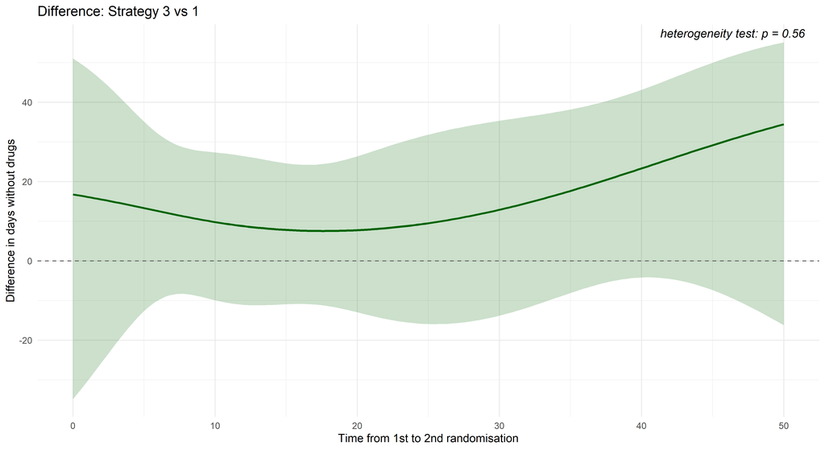

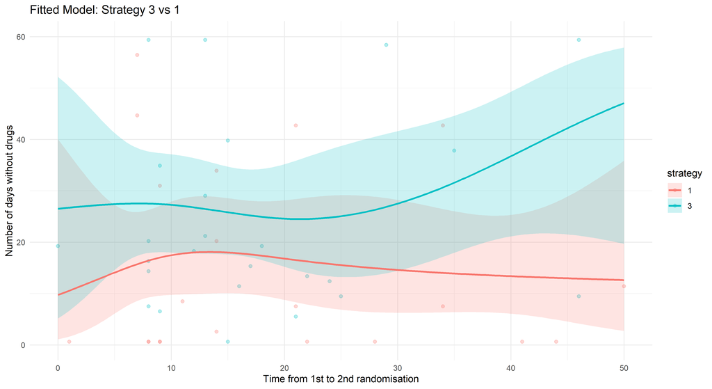

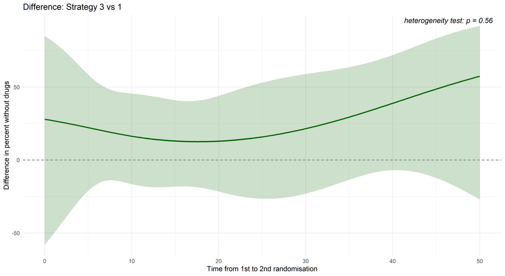

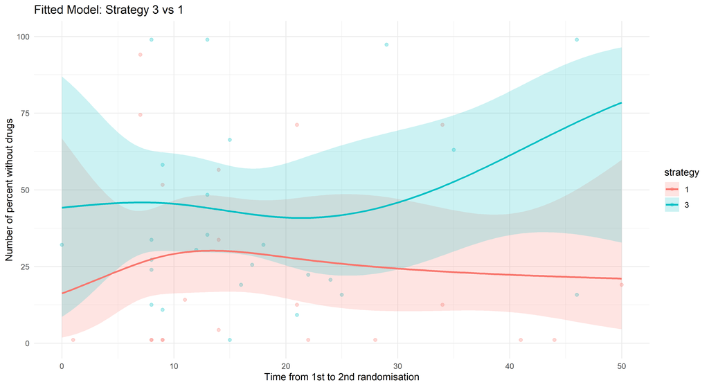

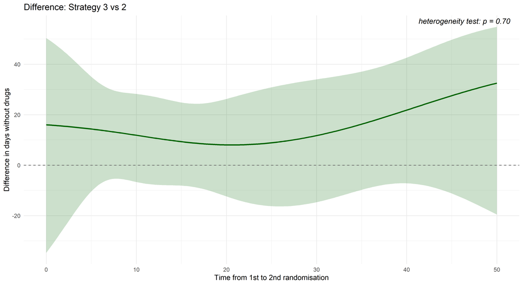

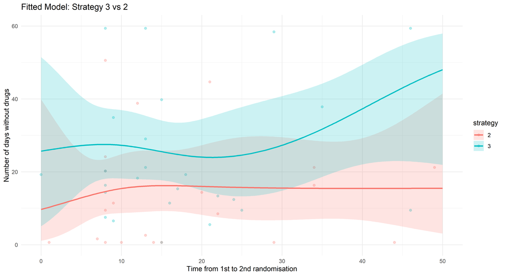

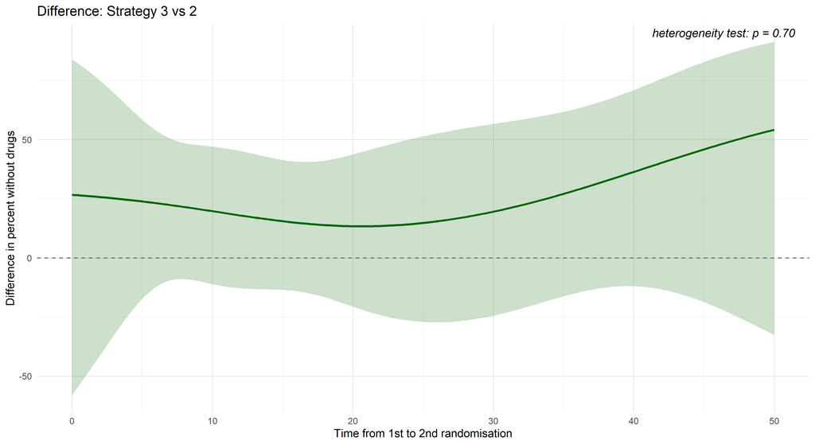

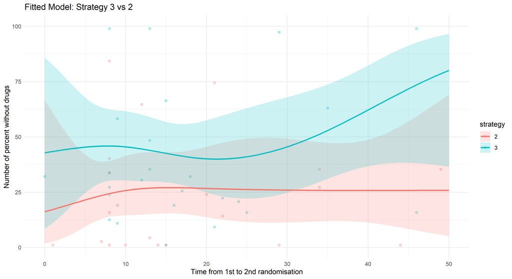

### 2.3 Swimmer plot

IDs were ordered from the highest to the lowest proportion of time in the 60 days following randomisation during which neither rifampicin nor isoniazid were given. The actual IDs were then relabelled.

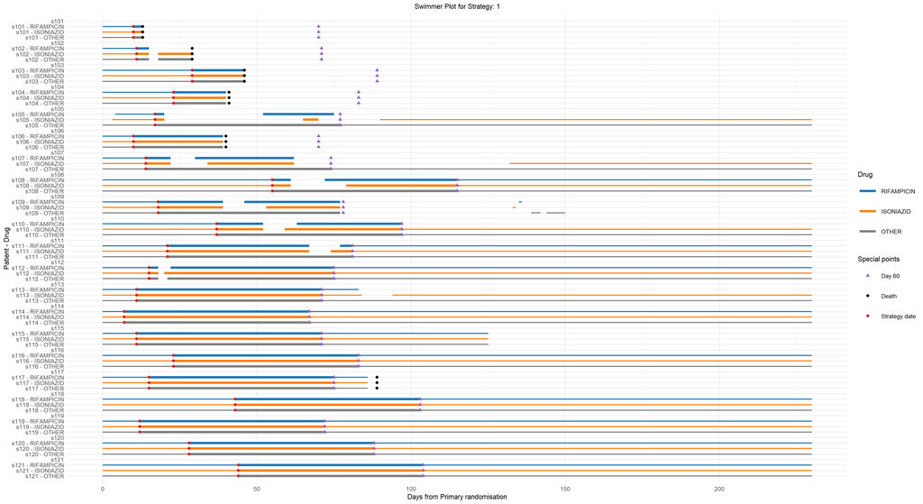

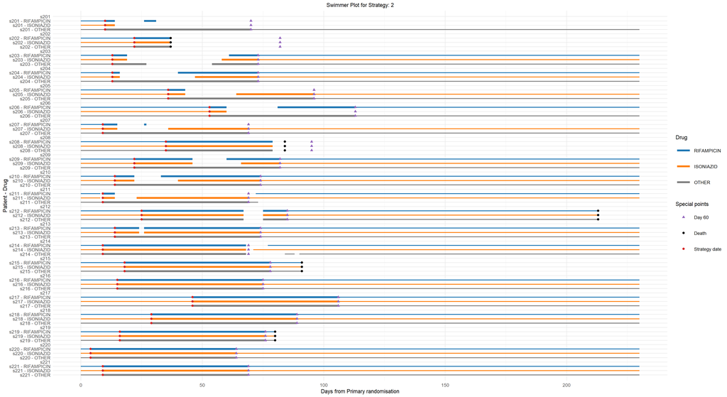

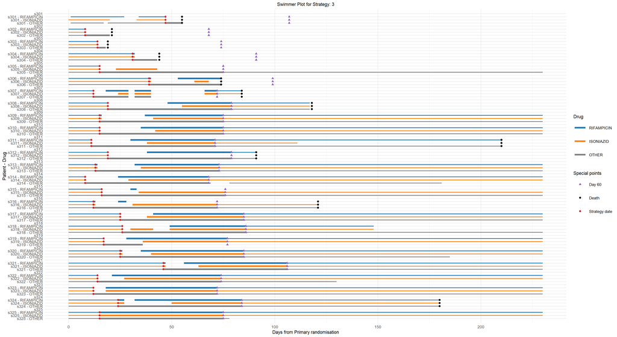

## 3. Secondary outcomes

### 3.1 Development of acute liver failure from DILI randomisation until 12 months from first randomisation

There was no event. Acute liver failure is defined as new onset coagulopathy (INR>1.5) and hepatic encephalopathy after randomisation.

### 3.2 Strategy failure

Strategy failure is defined as switch to strategy 3 due to worsening liver toxicity.

| Subgroup | Strategy 1 | Strategy 2 | P-value1 | Heterogeneity |
| --- | --- | --- | --- | --- |
| Overall | 8/21 | 13/21 | 0.22 |  |
| HIV status |  |  |  | 0.76 |
| - Positive | 3/9 | 5/8 | 0.47 |  |
| - Negative | 5/12 | 8/13 | 0.55 |  |
| Corticosteroid allocation |  |  |  | 0.66 |
| - Placebo | 3/9 | 7/13 | 0.61 |  |
| - Dexamethasone | 5/12 | 6/8 | 0.31 |  |

1P-value are computed based on Chisquared test with continuty correction.

| **Characteristic** | **1** N = 21<sup>1</sup> | **2** N = 21<sup>1</sup> | **3** N = 25<sup>1</sup> |
| --- | --- | --- | --- |
| Did ALT rise to ≥10x normal? | 2 / 21 (9.5%) | n.a. | n.a. |
| Did ALT remain elevated ≥5x ULN by day 6? | n.a. | 8 / 21 (38%) | n.a. |
| Did total bilirubin rise to >43 µmol/L? | 5 / 21 (24%) | 4 / 21 (19%) | 5 / 25 (20%) |
| Did INR rise to >1.5? | 0 / 19 (0%) | 0 / 20 (0%) | 0 / 23 (0%) |
| Unknown | 2 | 1 | 2 |
| Did symptoms of hepatitis worsen(nausea, vomiting, abdominal pain)? | 4 / 21 (19%) | 2 / 21 (9.5%) | 4 / 25 (16%) |
| Was RHZ stopped? | 8 / 21 (38%) | 13 / 21 (62%) | n.a. |

<sup>1</sup> n.a.: not applicable

### 3.3 Time to new neurological event or death from DILI randomisation until 12 months from first randomisation

#### 3.3.1 Kaplan-Meier plots

**Overall**

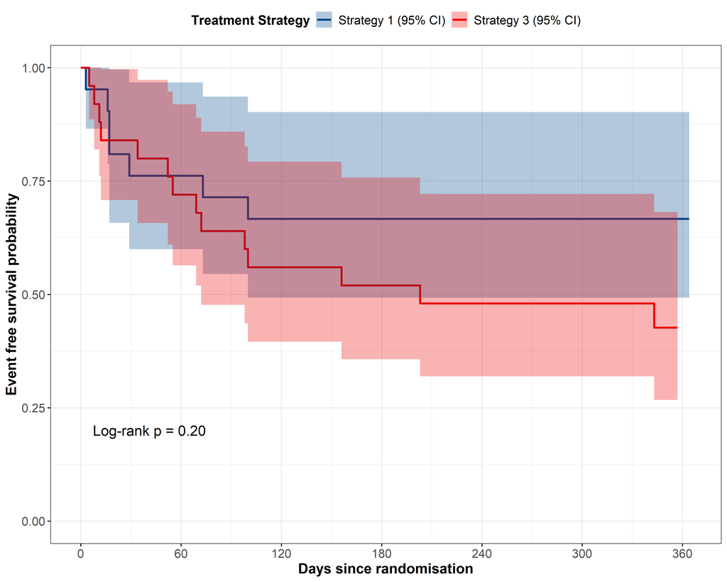

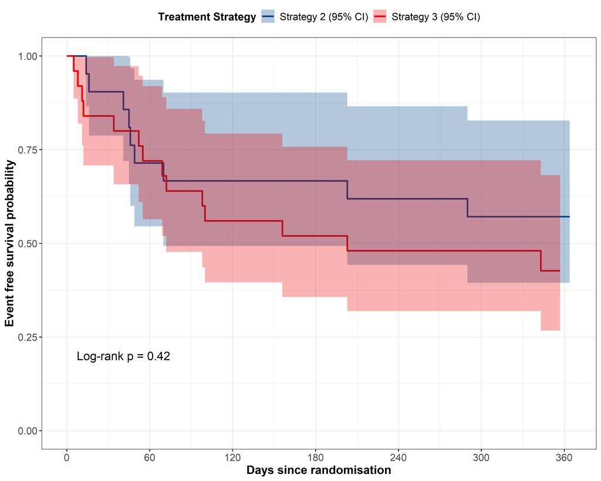

**With stratification by HIV Status**

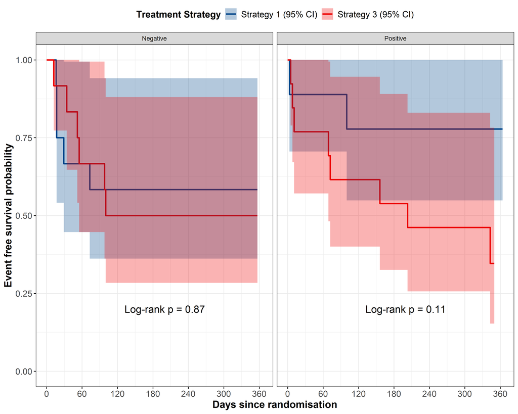

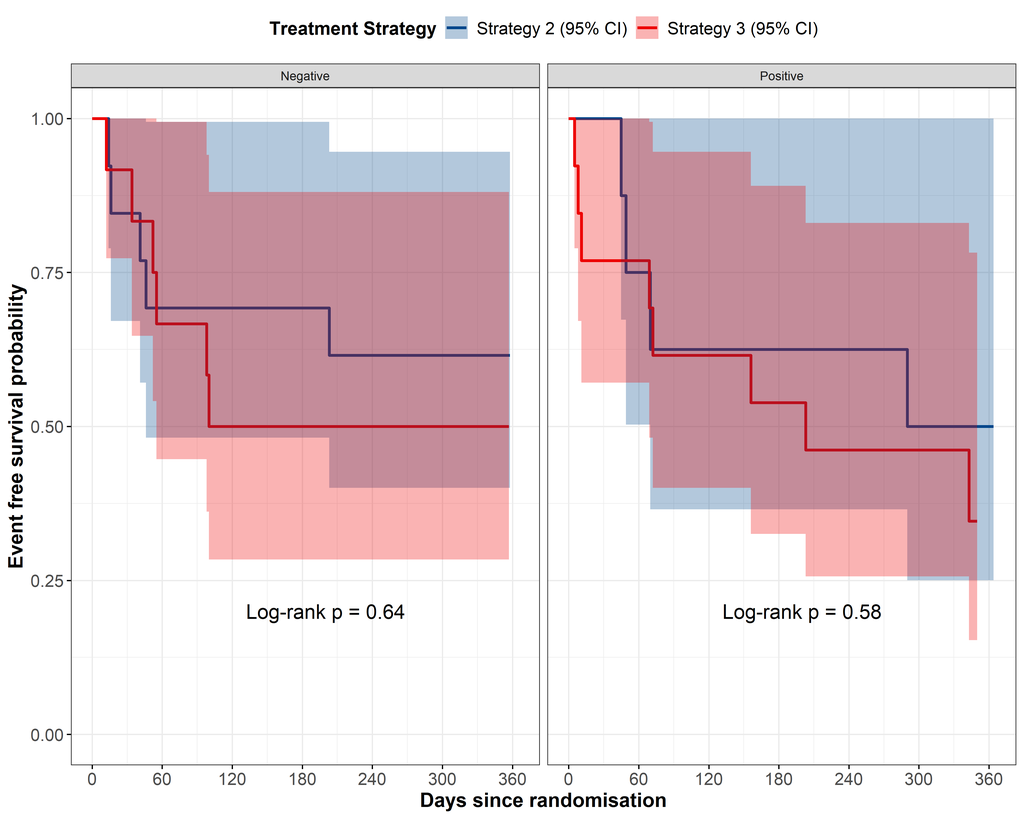

**With stratification by corticosteroids allocation**

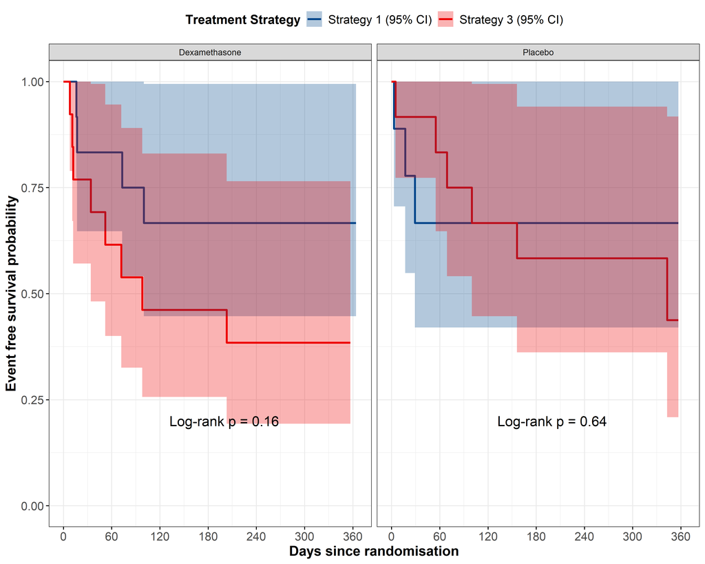

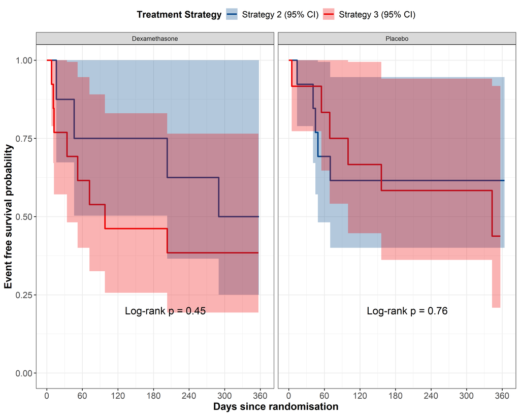

**With stratification by neurological event before DILI**

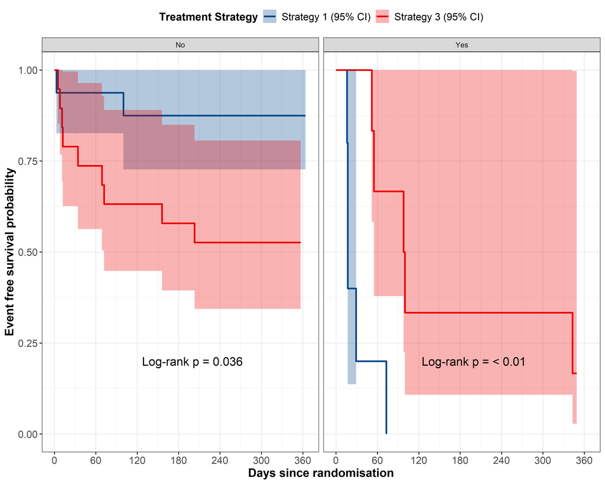

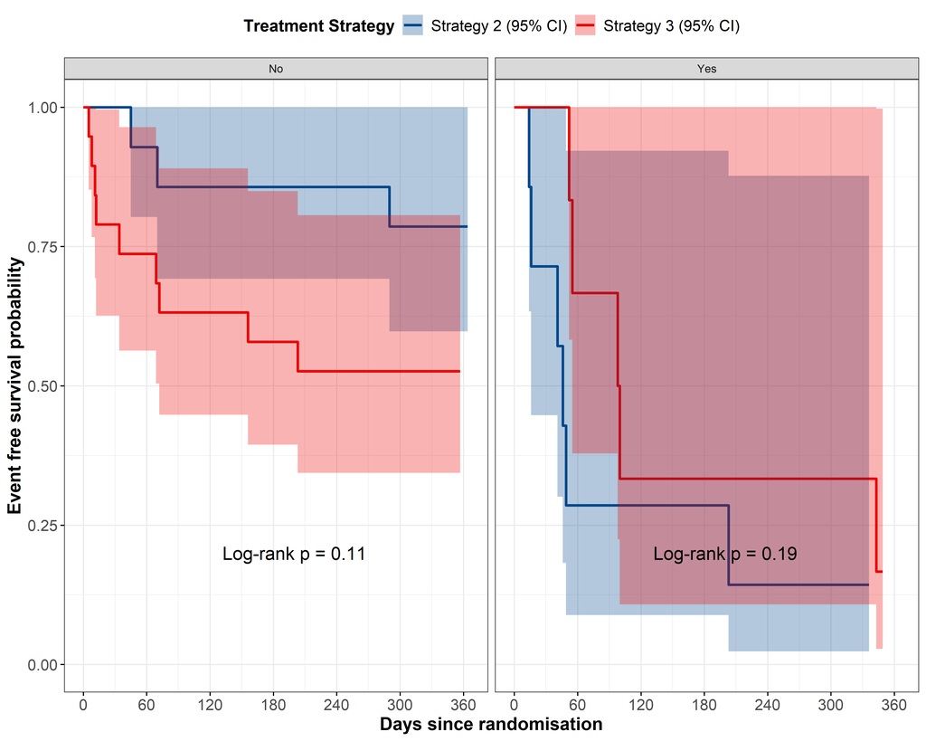

#### 3.3.2 Cox proportional hazard model:

**Strategy 1 vs Strategy 3:**

| Subgroup | Strategy 3 (n=25) events/n | Strategy 1 (n=21) events/n | Comparison HR (95%CI); p-value | Test for heterogeneity p-value |
| --- | --- | --- | --- | --- |
| All patients | 14/25 | 7/21 | 0.58 (0.23-1.36); p=0.213 |  |
| Status HIV |  |  |  | 0.081 |
| - Negative | 6/12 | 5/12 | 0.92 (0.28-2.90); p=0.883 |  |
| - Positive | 8/13 | 2/9 | 0.36 (0.07-1.31); p=0.126 |  |
| Corticosteroid allocation |  |  |  | 0.133 |
| - Dexamethasone | 8/13 | 4/12 | 0.45 (0.13-1.38); p=0.166 |  |
| - Placebo | 6/12 | 3/9 | 0.77 (0.18-2.73); p=0.693 |  |
| Neurological events before dili |  |  |  | <0.01 |
| - No | 9/19 | 2/16 | 0.26 (0.05-0.93); p=0.038 |  |
| - Yes | 5/6 | 5/5 | 6.40 (1.43-37.40); p=0.015 |  |

HR = hazard ratio Test for heterogeneity is an Likelihood-ratio test for interaction between treatment effect and each subgroup in the survival model not including other variables.

**Strategy 2 vs Strategy 3:**

| Subgroup | Strategy 3 (n=25) events/n | Strategy 2 (n=21) events/n | Comparison HR (95%CI); p-value | Test for heterogeneity p-value |
| --- | --- | --- | --- | --- |
| All patients | 14/25 | 9/21 | 0.72 (0.31-1.62); p=0.431 |  |
| Status HIV |  |  |  | 0.136 |
| - Negative | 6/12 | 5/13 | 0.77 (0.23-2.42); p=0.644 |  |
| - Positive | 8/13 | 4/8 | 0.75 (0.22-2.29); p=0.624 |  |
| Corticosteroid allocation |  |  |  | 0.164 |
| - Dexamethasone | 8/13 | 4/8 | 0.67 (0.19-2.03); p=0.487 |  |
| - Placebo | 6/12 | 5/13 | 0.84 (0.26-2.66); p=0.768 |  |
| Neurological events before dili |  |  |  | 0.02 |
| - No | 9/19 | 3/14 | 0.39 (0.10-1.24); p=0.115 |  |
| - Yes | 5/6 | 6/7 | 2.24 (0.66-8.29); p=0.193 |  |

HR = hazard ratio Test for heterogeneity is an Likelihood-ratio test for interaction between treatment effect and each subgroup in the survival model not including other variables.

### 3.4 Overall survival from DILI randomisation until 12 months from first randomisation

#### 3.4.1 Kaplan-Meier plots

**Overall**

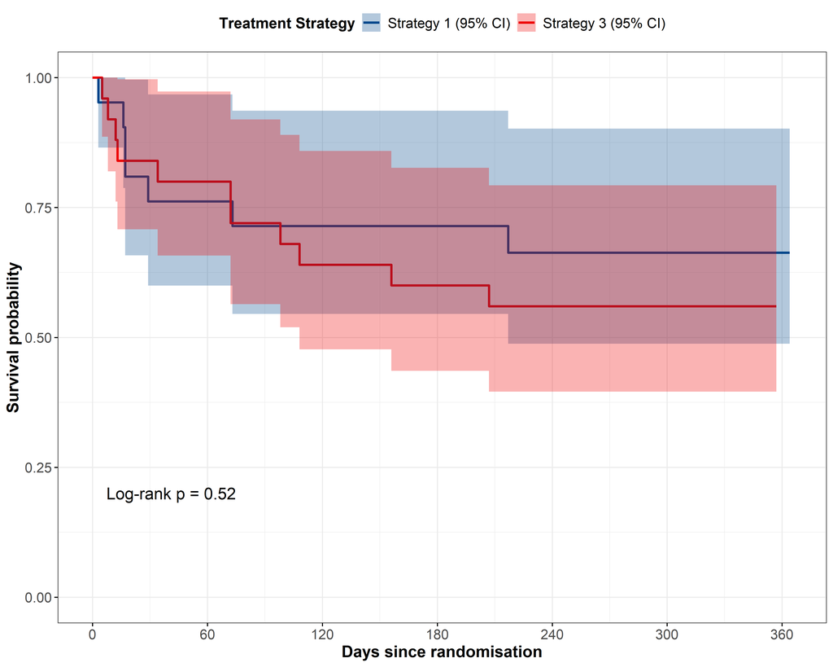

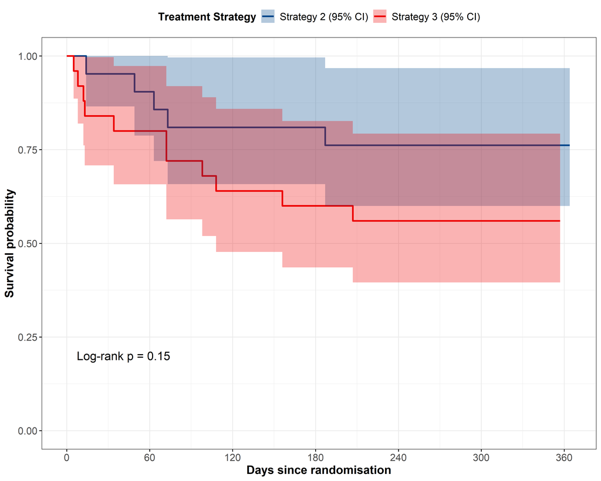

**With stratification by HIV Status**

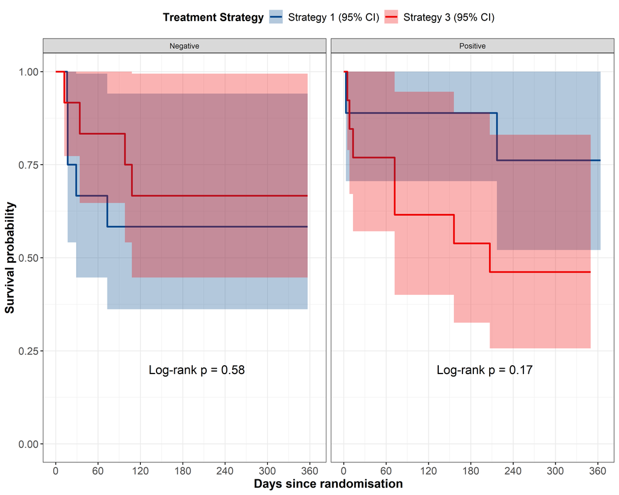

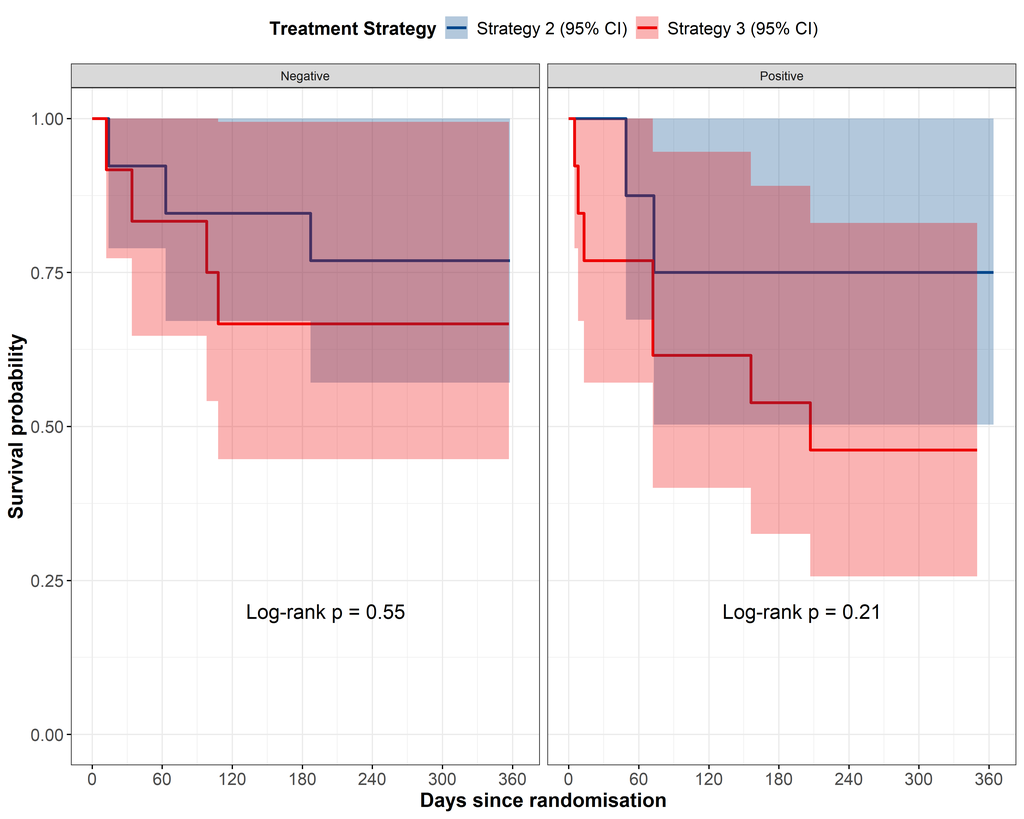

**With stratification by corticosteroids allocation**

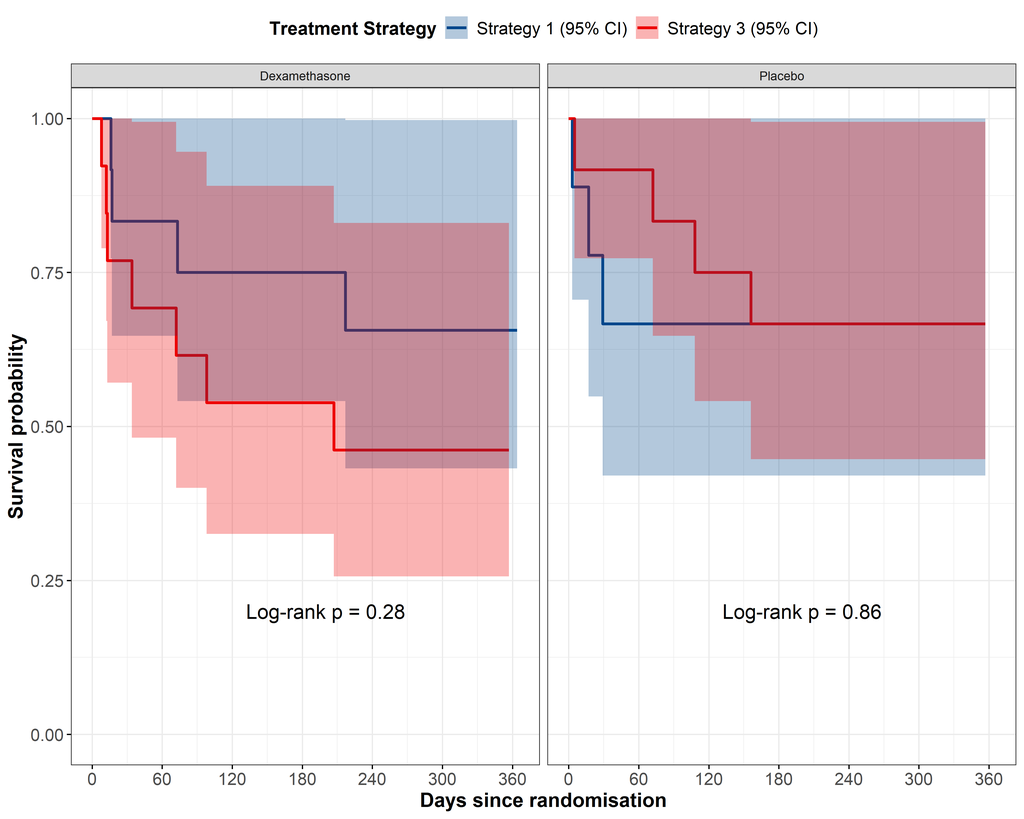

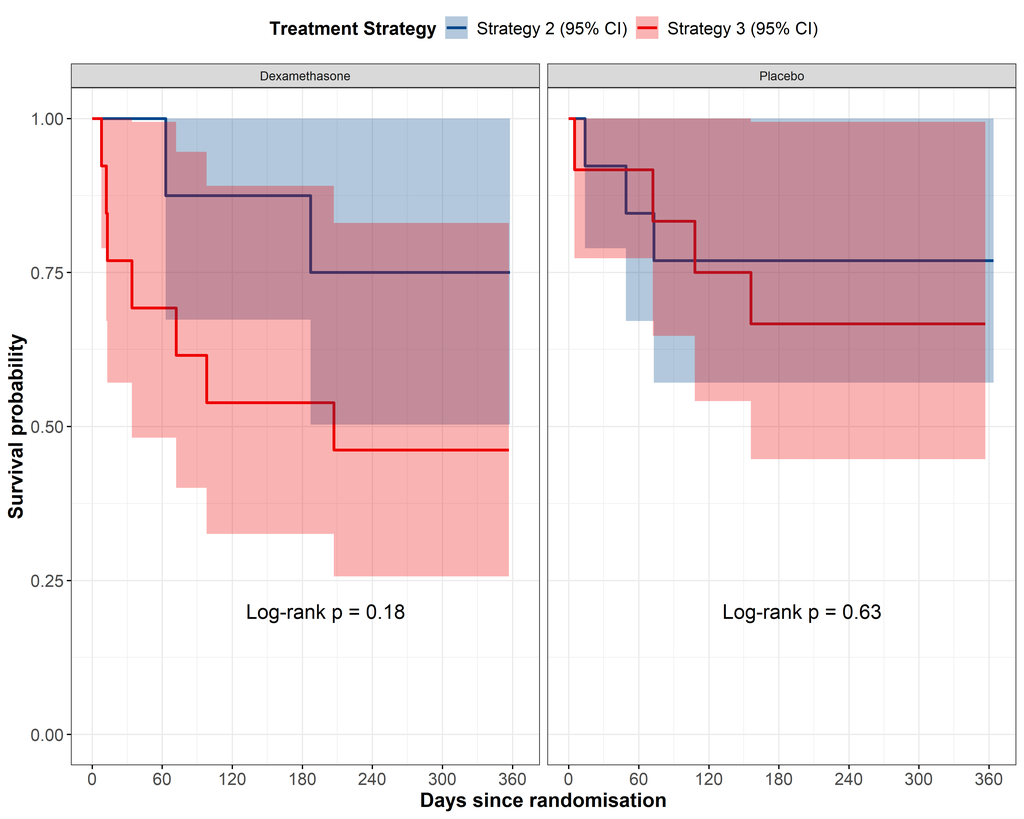

**With stratification by neurological event before DILI**

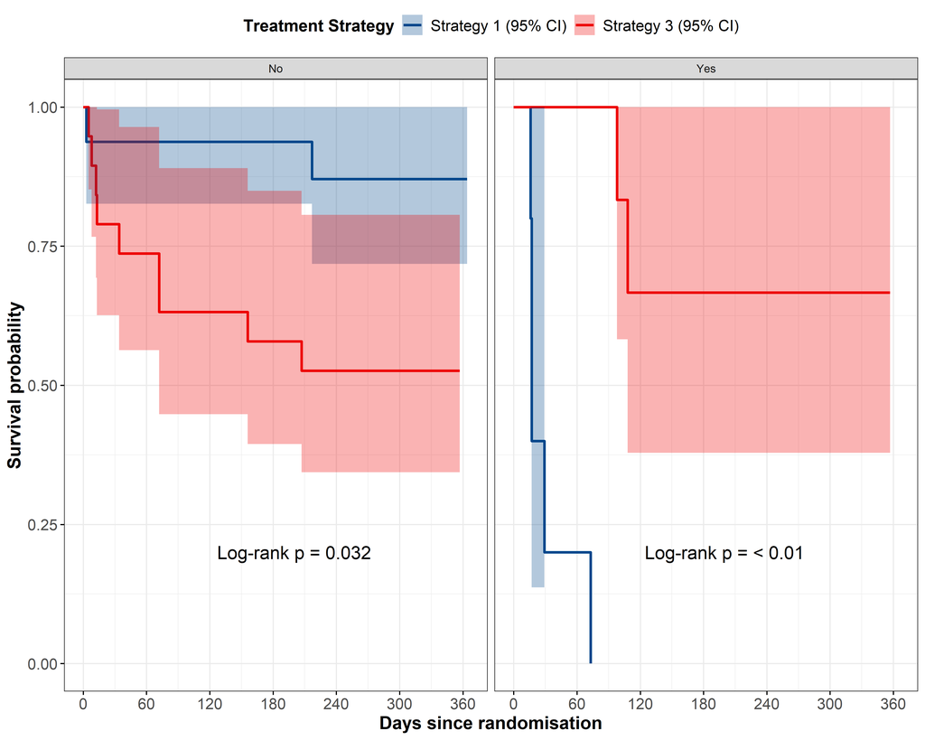

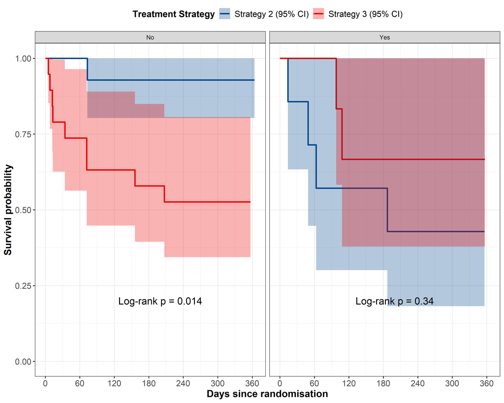

#### 3.4.2 Cox proportional hazard model:

Note the section of neurological events before DILI are highly significant, although the numbers are small. The subgroup Neurological events before DILI was not included in the original SAP. However, during the analysis of the third secondary outcome (Section 3.3), we realized that participants who experienced neurological events prior to DILI should be excluded from the analysis of new neurological events associated with DILI. In contrast, for the fourth secondary outcome—overall survival—there is no need to exclude these participants. Nevertheless, we aimed to explore whether having neurological events before DILI influences the effect of the DILI strategy.

**Strategy 1 vs Strategy 3:**

| Subgroup | Strategy 3 (n=25) events/n | Strategy 1 (n=21) events/n | Comparison HR (95%CI); p-value | Test for heterogeneity p-value |
| --- | --- | --- | --- | --- |
| All patients | 11/25 | 7/21 | 0.75 (0.29-1.87); p=0.544 |  |
| Status HIV |  |  |  | 0.058 |
| - Negative | 4/12 | 5/12 | 1.41 (0.40-5.26); p=0.59 |  |
| - Positive | 7/13 | 2/9 | 0.41 (0.08-1.55); p=0.199 |  |
| Corticosteroid allocation |  |  |  | 0.116 |
| - Dexamethasone | 7/13 | 4/12 | 0.54 (0.15-1.70); p=0.293 |  |
| - Placebo | 4/12 | 3/9 | 1.19 (0.27-4.90); p=0.808 |  |
| Neurological events before dili |  |  |  | <0.01 |
| - No | 9/19 | 2/16 | 0.26 (0.05-0.91); p=0.035 |  |
| - Yes | 2/6 | 5/5 | 29.69 (3.03-3999.91); p=<0.01 |  |

HR = hazard ratio Test for heterogeneity is an Likelihood-ratio test for interaction between treatment effect and each subgroup in the survival model not including other variables.

**Strategy 2 vs Strategy 3:**

| Subgroup | Strategy 3 (n=25) events/n | Strategy 2 (n=21) events/n | Comparison HR (95%CI); p-value | Test for heterogeneity p-value |
| --- | --- | --- | --- | --- |
| All patients | 11/25 | 5/21 | 0.49 (0.16-1.32); p=0.161 |  |
| Status HIV |  |  |  | 0.164 |
| - Negative | 4/12 | 3/13 | 0.66 (0.15-2.72); p=0.56 |  |
| - Positive | 7/13 | 2/8 | 0.45 (0.08-1.68); p=0.247 |  |
| Corticosteroid allocation |  |  |  | 0.189 |
| - Dexamethasone | 7/13 | 2/8 | 0.42 (0.08-1.57); p=0.205 |  |
| - Placebo | 4/12 | 3/13 | 0.72 (0.16-2.96); p=0.644 |  |
| Neurological events before dili |  |  |  | <0.01 |
| - No | 9/19 | 1/14 | 0.17 (0.02-0.72); p=0.014 |  |
| - Yes | 2/6 | 4/7 | 2.02 (0.44-11.65); p=0.364 |  |

HR = hazard ratio Test for heterogeneity is an Likelihood-ratio test for interaction between treatment effect and each subgroup in the survival model not including other variables.

### 3.5 Neurological disability at 12 months from first randomisation

**Strategy 1 vs Strategy 3:**

| Subgroup | Strategy 3 (n=25) events/n | Strategy 1 (n=21) events/n | Comparison OR (95%CI); p-value | Test for heterogeneity p-value |
| --- | --- | --- | --- | --- |
| All patients | 12/25 | 10/21 | 0.98 (0.31-3.17); p=0.98 |  |
| HIV status |  |  |  | 0.141 |
| - Positive | 8/13 | 5/9 | 0.78 (0.13-4.53); p=0.78 |  |
| - Negative | 4/12 | 5/12 | 1.43 (0.27-7.94); p=0.67 |  |
| All patients | 12/25 | 10/21 | 0.98 (0.31-3.17); p=0.98 |  |
| Corticosteroid allocation |  |  |  | 0.223 |
| - Placebo | 5/12 | 3/9 | 0.70 (0.11-4.18); p=0.70 |  |
| - Dexamethasone | 7/13 | 7/12 | 1.20 (0.24-6.05); p=0.82 |  |

OR = Odds ratio Neurological disability will be compared via the chi-squared test for independence (or Fisher’s exact test if expected number of events under the null hypothesis is <=1 in at least one of the cells). The test for heterogeneity was based on a logistic regression model.

**Strategy 2 vs Strategy 3:**

| Subgroup | Strategy 3 (n=25) events/n | Strategy 2 (n=21) events/n | Comparison OR (95%CI); p-value | Test for heterogeneity p-value |
| --- | --- | --- | --- | --- |
| All patients | 12/25 | 7/21 | 0.54 (0.16-1.77); p=0.32 |  |
| HIV status |  |  |  | 0.199 |
| - Positive | 8/13 | 3/8 | 0.38 (0.05-2.22); p=0.29 |  |
| - Negative | 4/12 | 4/13 | 0.89 (0.16-4.94); p=0.89 |  |
| All patients | 12/25 | 7/21 | 0.54 (0.16-1.77); p=0.32 |  |
| Corticosteroid allocation |  |  |  | 0.503 |
| - Placebo | 5/12 | 4/13 | 0.62 (0.11-3.22); p=0.57 |  |
| - Dexamethasone | 7/13 | 3/8 | 0.51 (0.08-3.04); p=0.47 |  |

OR = Odds ratio Neurological disability was compared via the chi-squared test for independence. The test for heterogeneity was based on a logistic regression model.